# Evaluación 3

```python
import os


import geopandas as gpd
from  fiona import listlayers

#maps
australiaMaps='https://github.com/SpatialDataScience23-2/evaluacion3/raw/main/maps/australiaMaps_3112.gpkg'

#layers in maps
listlayers(australiaMaps)
```

```
['country', 'cities', 'rivers']
```

```python
australia=gpd.read_file(australiaMaps,layer='country')
australia_cities=gpd.read_file(australiaMaps,layer='cities')
australia_rivers=gpd.read_file(australiaMaps,layer='rivers')
```

```python
australia.crs.to_epsg()==australia_cities.crs.to_epsg()==australia_rivers.crs.to_epsg()
```

```
True
```

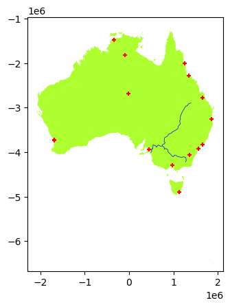

```python
# plotting
base = australia.plot(facecolor="greenyellow")
australia_rivers.plot(edgecolor='blue', linewidth=0.5,ax=base)
australia_cities.plot(marker='+', color='red', markersize=15,ax=base)
```

### Exercise 1

1. Check if your country is a polygon or multipolygon. 2. Recover just the boundaries of that country. 3. Turn the boundary into a GDF.

## Formating Geoseries projections

```python
australia
```

|  | COUNTRY | geometry |
| --- | --- | --- |
| 0 | Australia | MULTIPOLYGON (((933348.661 -1235788.329, 92574... |

```python
australia.boundary
```

```
0    MULTILINESTRING ((933348.661 -1235788.329, 925...
dtype: geometry
```

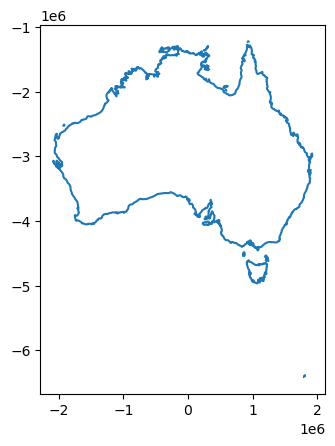

```python
# This is just the borderline
australia.boundary.plot()
```

```python
# does 'boundary' return a GDF?
type(australia.boundary)
```

```
geopandas.geoseries.GeoSeries
```

```python
# converting into GDF
australia.boundary.to_frame()
```

|  | 0 |
| --- | --- |
| 0 | MULTILINESTRING ((933348.661 -1235788.329, 925... |

```python
# conversion
australia_border=australia.boundary.to_frame()

# new column (optional)
australia_border['name']='Australia'

# renaming the geometry column
australia_border.rename(columns={0:'geometry'},inplace=True)

#setting the geometry (the name is not enough)
australia_border = australia_border.set_geometry("geometry")

# verifying:
australia_border.crs
```

```
<Projected CRS: EPSG:3112>
Name: GDA94 / Geoscience Australia Lambert
Axis Info [cartesian]:
- E[east]: Easting (metre)
- N[north]: Northing (metre)
Area of Use:
- name: Australia - Australian Capital Territory; New South Wales; Northern Territory; Queensland; South Australia; Tasmania; Western Australia; Victoria.
- bounds: (112.85, -43.7, 153.69, -9.86)
Coordinate Operation:
- name: Geoscience Australia Standard National Scale Lambert Projection
- method: Lambert Conic Conformal (2SP)
Datum: Geocentric Datum of Australia 1994
- Ellipsoid: GRS 1980
- Prime Meridian: Greenwich
```

```python
australia_border
```

|  | geometry | name |
| --- | --- | --- |
| 0 | MULTILINESTRING ((933348.661 -1235788.329, 925... | Australia |

### Exercise 2

1. Look for sub administrative divisions of your country 2. Check all the CRSs of those divisions 3. If you find one CRS is missing, fill the CRS with the right projection.

## Lacking CRS information

Reprojecting seems a simple process, but you might find some interesting cases. Let's read the maps on *states* and *municipalities*:

```python
australia_states=gpd.read_file(os.path.join("maps","gadm41_AUS_shp","gadm41_AUS_1.shp"))
australia_municipalities=gpd.read_file(os.path.join("maps","gadm41_AUS_shp","gadm41_AUS_2.shp"))
```

```python
#print(australia_municipalities.columns)
```

```python
australia_states.crs, australia_municipalities.crs
```

```
(<Geographic 2D CRS: EPSG:4326>
 Name: WGS 84
 Axis Info [ellipsoidal]:
 - Lat[north]: Geodetic latitude (degree)
 - Lon[east]: Geodetic longitude (degree)
 Area of Use:
 - name: World.
 - bounds: (-180.0, -90.0, 180.0, 90.0)
 Datum: World Geodetic System 1984 ensemble
 - Ellipsoid: WGS 84
 - Prime Meridian: Greenwich,
 <Geographic 2D CRS: EPSG:4326>
 Name: WGS 84
 Axis Info [ellipsoidal]:
 - Lat[north]: Geodetic latitude (degree)
 - Lon[east]: Geodetic longitude (degree)
 Area of Use:
 - name: World.
 - bounds: (-180.0, -90.0, 180.0, 90.0)
 Datum: World Geodetic System 1984 ensemble
 - Ellipsoid: WGS 84
 - Prime Meridian: Greenwich)
```

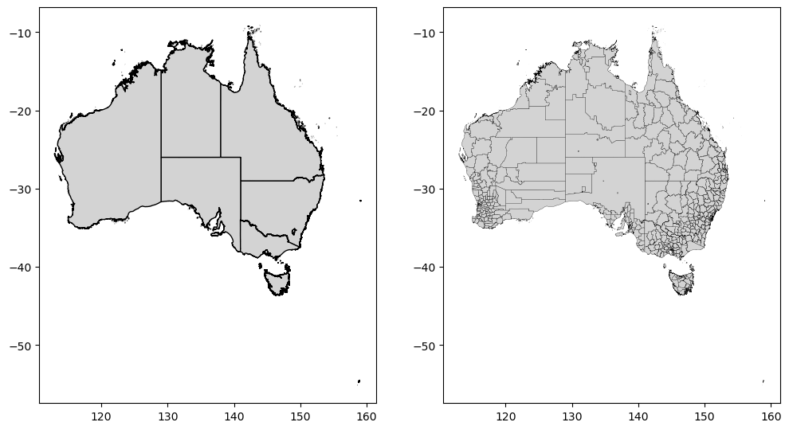

```python
import matplotlib.pyplot as plt

fig, (ax1, ax2) = plt.subplots(ncols=2, sharex=False, sharey=False, figsize=(12,12))
australia_states.plot(ax=ax1, facecolor='lightgrey', edgecolor='black')
australia_municipalities.plot(ax=ax2, facecolor='lightgrey', edgecolor='black',linewidth=0.2)
```

```python
australia_states.to_crs(3112)
```

|  | GID_1 | GID_0 | COUNTRY | NAME_1 | VARNAME_1 | NL_NAME_1 | TYPE_1 | ENGTYPE_1 | CC_1 | HASC_1 | ISO_1 | geometry |
| --- | --- | --- | --- | --- | --- | --- | --- | --- | --- | --- | --- | --- |
| 0 | AUS.1_1 | AUS | Australia | Ashmore and Cartier Islands | NA | NA | Territory | Territory | 12 | AU.AS | NA | MULTIPOLYGON (((-1155528.973 -1509855.849, -11... |
| 1 | AUS.2_1 | AUS | Australia | Australian Capital Territory | NA | NA | Territory | Territory | 8 | AU.AC | AU-ACT | POLYGON ((1377837.616 -4045794.766, 1377835.52... |
| 2 | AUS.3_1 | AUS | Australia | Coral Sea Islands Territory | NA | NA | Territory | Territory | 11 | AU.CR | NA | MULTIPOLYGON (((2171096.644 -2836891.086, 2171... |
| 3 | AUS.4_1 | AUS | Australia | Jervis Bay Territory | NA | NA | Territory | Territory | 10 | AU.JB | NA | MULTIPOLYGON (((1512782.961 -4060699.652, 1512... |
| 4 | AUS.5_1 | AUS | Australia | New South Wales | NA | NA | State | State | 1 | AU.NS | AU-NSW | MULTIPOLYGON (((1425477.420 -4282022.059, 1425... |
| 5 | AUS.6_1 | AUS | Australia | Northern Territory | NA | NA | Territory | Territory | 7 | AU.NT | AU-NT | MULTIPOLYGON (((396919.115 -2912009.360, 39663... |
| 6 | AUS.7_1 | AUS | Australia | Queensland | NA | NA | State | State | 3 | AU.QL | AU-QLD | MULTIPOLYGON (((1888723.119 -3335704.807, 1888... |
| 7 | AUS.8_1 | AUS | Australia | South Australia | NA | NA | State | State | 4 | AU.SA | AU-SA | MULTIPOLYGON (((588130.207 -4295631.676, 58812... |
| 8 | AUS.9_1 | AUS | Australia | Tasmania | NA | NA | State | State | 6 | AU.TS | AU-TAS | MULTIPOLYGON (((1775447.870 -6460286.466, 1775... |
| 9 | AUS.10_1 | AUS | Australia | Victoria | NA | NA | State | State | 2 | AU.VI | AU-VIC | MULTIPOLYGON (((1072497.608 -4455108.029, 1072... |
| 10 | AUS.11_1 | AUS | Australia | Western Australia | NA | NA | State | State | 5 | AU.WA | AU-WA | MULTIPOLYGON (((-1097002.018 -3933989.539, -10... |

```python
australia_states.geometry.head()
```

```
0    MULTIPOLYGON (((123.55544 -12.53185, 123.55537...
1    POLYGON ((149.20070 -35.20541, 149.20070 -35.2...
2    MULTIPOLYGON (((155.53674 -23.25240, 155.53647...
3    MULTIPOLYGON (((150.69450 -35.18469, 150.69438...
4    MULTIPOLYGON (((150.05190 -37.26310, 150.05199...
Name: geometry, dtype: geometry
```

```python
australia_states.crs = "EPSG:4326"
australia_municipalities.crs = "EPSG:4326"
```

```python
australia_states=australia_states.to_crs(3112)
australia_municipalities=australia_municipalities.to_crs(3112)
```

### Exercise 3

1. Look for some points in a CSV file about your country. 2. Turn those points into a spatial object. 3. Save the layer.